# Binary segmentation examples

In this vignette we explore the differences in asymptotic time complexity between different implementations of binary segmentation.

## Asymptotic time/memory measurement of different R expressions

The code below uses the following arguments:

- `N` is a numeric vector of data sizes,
- `setup` is an R expression to create the data,
- the other arguments have names to identify them in the results, and values which are R expressions to time,

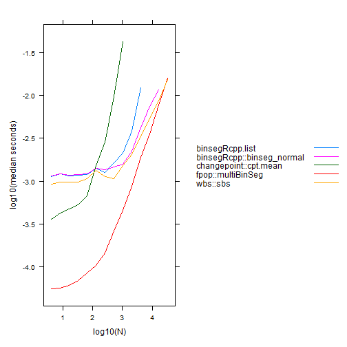

```r
library(data.table)
atime.list <- atime::atime(
  N=2^seq(2, 20),
  setup={
    max.segs <- as.integer(N/2)
    max.changes <- max.segs-1L
    set.seed(1)
    data.vec <- 1:N
  },
  "changepoint::cpt.mean"={
    cpt.fit <- changepoint::cpt.mean(data.vec, method="BinSeg", Q=max.changes)
    sort(c(N,cpt.fit@cpts.full[max.changes,]))
  },
  "binsegRcpp::binseg_normal"={
    binseg.fit <- binsegRcpp::binseg_normal(data.vec, max.segs)
    sort(binseg.fit$splits$end)
  },
  "fpop::multiBinSeg"={
    mbs.fit <- fpop::multiBinSeg(data.vec, max.changes)
    sort(c(mbs.fit$t.est, N))
  },
  "wbs::sbs"={
    wbs.fit <- wbs::sbs(data.vec)
    split.dt <- data.table(wbs.fit$res)[order(-min.th, scale)]
    sort(split.dt[, c(N, cpt)][1:max.segs])
  },
  binsegRcpp.list={
    binseg.fit <- binsegRcpp::binseg(
      "mean_norm", data.vec, max.segs, container.str="list")
    sort(binseg.fit$splits$end)
  },
  ##seconds.limit=0.1,
  times=5)
plot(atime.list)
```

The default plot method creates a log-log plot of median time vs data size, for each of the specified R expressions. You can use `references_best` to get a tall/long data table that can be plotted to show both empirical time and memory complexity:

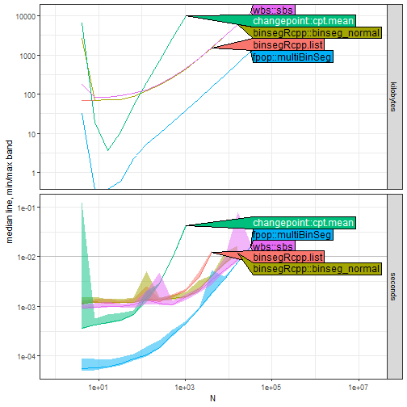

```r
best.list <- atime::references_best(atime.list)
if(require(ggplot2)){
  hline.df <- with(atime.list, data.frame(seconds.limit, unit="seconds"))
  gg.both <- ggplot()+
    theme_bw()+
    facet_grid(unit ~ ., scales="free")+
    geom_hline(aes(
      yintercept=seconds.limit),
      color="grey",
      data=hline.df)+
    geom_line(aes(
      N, empirical, color=expr.name),
      data=best.list$meas)+
    geom_ribbon(aes(
      N, ymin=min, ymax=max, fill=expr.name),
      data=best.list$meas[unit=="seconds"],
      alpha=0.5)+
    scale_x_log10()+
    scale_y_log10("median line, min/max band")
  if(require(directlabels)){
    gg.both+
      directlabels::geom_dl(aes(
        N, empirical, color=expr.name, label=expr.name),
        method="right.polygons",
        data=best.list$meas)+
      theme(legend.position="none")+
      coord_cartesian(xlim=c(1,2e7))
  }else{
    gg.both
  }
}
```

The plots above show some speed differences between binary segmentation algorithms, but they could be even easier to see for larger data sizes (exercise for the reader: try modifying the `N` and `seconds.limit` arguments). You can also see that memory usage is much larger for changepoint than for the other packages.

## Closest asymptotic references

You can use code like below to compute asymptotic references which are best fit for each expression. We do the best fit by adjusting each reference to the largest N, and then ranking each reference by distance to the measurement of the second to largest N. The code below uses `each.sign.rank==1` to compute the closest reference above and below,

```r
best.refs <- best.list$ref[each.sign.rank==1]
(time.refs <- best.refs[unit=="seconds"])
```

```
#>        unit                 expr.name   fun.latex  fun.name     N empirical
#>      <char>                    <char>      <char>    <char> <num>     <num>
#>  1: seconds     changepoint::cpt.mean N^2 \\log N N^2 log N    64 0.0006806
#>  2: seconds     changepoint::cpt.mean N^2 \\log N N^2 log N   128 0.0015243
#>  3: seconds     changepoint::cpt.mean N^2 \\log N N^2 log N   256 0.0028454
#>  4: seconds     changepoint::cpt.mean N^2 \\log N N^2 log N   512 0.0095882
#>  5: seconds     changepoint::cpt.mean N^2 \\log N N^2 log N  1024 0.0426579
#>  6: seconds     changepoint::cpt.mean         N^3       N^3   128 0.0015243
#>  7: seconds     changepoint::cpt.mean         N^3       N^3   256 0.0028454
#>  8: seconds     changepoint::cpt.mean         N^3       N^3   512 0.0095882
#>  9: seconds     changepoint::cpt.mean         N^3       N^3  1024 0.0426579
#> 10: seconds binsegRcpp::binseg_normal    \\sqrt N    sqrt N     4 0.0011581
#> 11: seconds binsegRcpp::binseg_normal    \\sqrt N    sqrt N     8 0.0012121
#> 12: seconds binsegRcpp::binseg_normal    \\sqrt N    sqrt N    16 0.0011799
#> 13: seconds binsegRcpp::binseg_normal    \\sqrt N    sqrt N    32 0.0012079
```

[output cut: 237 more lines]

Then you can plot these references with the empirical data using the ggplot code below,

```r
ref.color <- "red"
## try() to avoid CRAN error 'from' must be a finite number, on
## Flavors: r-devel-linux-x86_64-debian-gcc, r-release-linux-x86_64,
## due to https://github.com/r-lib/scales/issues/307
(seconds.dt <- best.list$meas[unit=="seconds"])
```

```
#>        unit     N                 expr.name       min    median     itr/sec
#>      <char> <num>                    <char>     <num>     <num>       <num>
#>  1: seconds     4     changepoint::cpt.mean 0.0003476 0.0003581  2664.35756
#>  2: seconds     8     changepoint::cpt.mean 0.0004182 0.0004255  2193.84845
#>  3: seconds    16     changepoint::cpt.mean 0.0004555 0.0004716  1955.49298
#>  4: seconds    32     changepoint::cpt.mean 0.0005064 0.0005301  1747.51852
#>  5: seconds    64     changepoint::cpt.mean 0.0006489 0.0006806  1432.74686
#>  6: seconds   128     changepoint::cpt.mean 0.0012199 0.0015243   635.27558
#>  7: seconds   256     changepoint::cpt.mean 0.0027500 0.0028454   350.86734
#>  8: seconds   512     changepoint::cpt.mean 0.0094915 0.0095882   104.04874
#>  9: seconds  1024     changepoint::cpt.mean 0.0425511 0.0426579    23.35668
#> 10: seconds     4 binsegRcpp::binseg_normal 0.0011419 0.0011581   809.06149
#> 11: seconds     8 binsegRcpp::binseg_normal 0.0011690 0.0012121   783.66221
#> 12: seconds    16 binsegRcpp::binseg_normal 0.0011571 0.0011799   817.98253
#> 13: seconds    32 binsegRcpp::binseg_normal 0.0011854 0.0012079   807.40226
```

[output cut: 369 more lines]

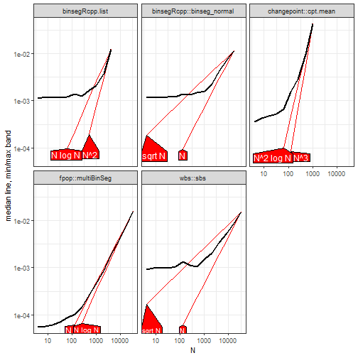

```r
try(if(require(ggplot2)){
  gg <- ggplot()+
    geom_line(aes(
      N, reference, group=fun.name),
      color=ref.color,
      data=time.refs)+
    geom_line(aes(
      N, empirical),
      size=1,
      data=seconds.dt)+
    scale_x_log10()+
    scale_y_log10("median line, min/max band")+
    facet_wrap("expr.name")+
    theme_bw()
  if(require(directlabels)){
    gg+
      directlabels::geom_dl(aes(
        N, reference, label=fun.name),
        data=time.refs,
        color=ref.color,
        method="bottom.polygons")
  }else{
    gg
  }
})
```

## Custom asymptotic references

If you have one or more expected time complexity classes that you want to compare with your empirical measurements, you can use the `fun.list` argument:

```r
my.refs <- list(
  "N \\log N"=function(N)log10(N) + log10(log(N)),
  "N^2"=function(N)2*log10(N),
  "N^3"=function(N)3*log10(N))
my.best <- atime::references_best(atime.list, fun.list=my.refs)
```

Note that in the code above, each R function should take as input the data size `N` and output log base 10 of the reference function.

```r
(my.best.time.refs <- my.best$ref[unit=="seconds"])
```

```
#>        unit                 expr.name fun.latex fun.name     N empirical
#>      <char>                    <char>    <char>   <char> <num>     <num>
#>  1: seconds     changepoint::cpt.mean N \\log N  N log N     8 0.0004255
#>  2: seconds     changepoint::cpt.mean N \\log N  N log N    16 0.0004716
#>  3: seconds     changepoint::cpt.mean N \\log N  N log N    32 0.0005301
#>  4: seconds     changepoint::cpt.mean N \\log N  N log N    64 0.0006806
#>  5: seconds     changepoint::cpt.mean N \\log N  N log N   128 0.0015243
#>  6: seconds     changepoint::cpt.mean N \\log N  N log N   256 0.0028454
#>  7: seconds     changepoint::cpt.mean N \\log N  N log N   512 0.0095882
#>  8: seconds     changepoint::cpt.mean N \\log N  N log N  1024 0.0426579
#>  9: seconds     changepoint::cpt.mean       N^2      N^2    64 0.0006806
#> 10: seconds     changepoint::cpt.mean       N^2      N^2   128 0.0015243
#> 11: seconds     changepoint::cpt.mean       N^2      N^2   256 0.0028454
#> 12: seconds     changepoint::cpt.mean       N^2      N^2   512 0.0095882
#> 13: seconds     changepoint::cpt.mean       N^2      N^2  1024 0.0426579
```

[output cut: 225 more lines]

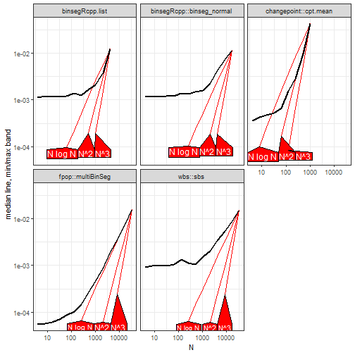

```r
try(if(require(ggplot2)){
  gg <- ggplot()+
    geom_line(aes(
      N, reference, group=fun.name),
      color=ref.color,
      data=my.best.time.refs)+
    geom_line(aes(
      N, empirical),
      size=1,
      data=seconds.dt)+
    scale_x_log10()+
    scale_y_log10("median line, min/max band")+
    facet_wrap("expr.name")+
    theme_bw()
  if(require(directlabels)){
    gg+
      directlabels::geom_dl(aes(
        N, reference, label=fun.name),
        data=my.best.time.refs,
        color=ref.color,
        method="bottom.polygons")
  }else{
    gg
  }
})
```

From the plot above you should be able to see the asymptotic time complexity class of each algorithm.

- the fastest packages are log-linear (fpop, wbs, binsegRcpp),
- that the binsegRcpp implementation that uses the list container is much slower (quadratic).
- the changepoint package uses a super-quadratic algorithm (actually cubic, which you could see if you increase N even larger).

## Exercises for the reader

- increase `seconds.limit` to see the differences more clearly.
- compute and plot asymptotic references for memory instead of time (including expected memory complexity, linear).